# Pod 3: Digital vs. Physical Textbooks

A replication of Atasoy & Morewedge (2018), *JCR*, Experiment 3

Published

November 12, 2026

This is the reproducible version of the Pod 3 section of *Estate Planning: Studies and Findings to Date*. Everything below is computed from `pod3_cleaned_data_11.12.26.csv` (613 participants).

# Did we replicate?

We ran their Experiment 3 – a 2 (format: printed vs. digital textbook) x 2 (acquisition: buy vs. rent) between-subjects design – and added the psychological ownership measure they used in their Experiment 2. Their published figures are in dollars, so this comparison runs on the raw dollar scale.

```r
ours <- contrasts_pooled(d$wtp)
av   <- peta(aov(wtp ~ format * acquisition, data = d))
own  <- peta(aov(ownership ~ format * acquisition, data = d))
mn   <- tapply(d$wtp, d$format, mean)

row_c <- function(i) sprintf("%s, p = %s, eta2 = %s",
                             money(ours$Diff[i]), ours$p[i], ours$`Partial eta2`[i])

kable(data.frame(
  Contrast = c("Buy: printed - digital", "Rent: printed - digital",
               "Printed: buy - rent", "Digital: buy - rent",
               "Format main effect", "Format x acquisition", "Ownership measured"),
  `Atasoy & Morewedge (N = 275)` = c(
    "+$42.91, p < .001, eta2 = .10",
    "+$11.80, p = .13, eta2 = .008",
    "+$28.84, p < .001, eta2 = .05",
    "-$2.27, p = .77",
    "$73.50 vs. $46.05, p < .001, eta2 = .08",
    "p = .005, eta2 = .03",
    "No"),
  `Pod 3 (N = 613)` = c(
    row_c(1), row_c(2), row_c(3), row_c(4),
    sprintf("$%.2f vs. $%.2f, p = %s, eta2 = %s", mn[["physical"]], mn[["digital"]],
            pick(av, "format", "p"), pick(av, "format", "Partial eta2")),
    sprintf("p = %s, eta2 = %s",
            pick(av, "format:acquisition", "p"), pick(av, "format:acquisition", "Partial eta2")),
    sprintf("Yes -- interaction p = %s, eta2 = %s",
            pick(own, "format:acquisition", "p"), pick(own, "format:acquisition", "Partial eta2"))),
  check.names = FALSE), row.names = FALSE,
  caption = "Our column is computed from the data; theirs is as published. Contrasts use the pooled error term, as they report them.")
```

Our column is computed from the data; theirs is as published. Contrasts use the pooled error term, as they report them.

| Contrast | Atasoy & Morewedge (N = 275) | Pod 3 (N = 613) |
| --- | --- | --- |
| Buy: printed - digital | +$42.91, p < .001, eta2 = .10 | +$9.83, p = 0.007, eta2 = 0.012 |
| Rent: printed - digital | +$11.80, p = .13, eta2 = .008 | +$1.81, p = 0.621, eta2 = 0.000 |
| Printed: buy - rent | +$28.84, p < .001, eta2 = .05 | +$2.27, p = 0.534, eta2 = 0.001 |
| Digital: buy - rent | -$2.27, p = .77 | -$5.74, p = 0.116, eta2 = 0.004 |
| Format main effect | $73.50 vs. $46.05, p < .001, eta2 = .08 | $45.95 vs. $40.13, p = 0.024, eta2 = 0.008 |
| Format x acquisition | p = .005, eta2 = .03 | p = 0.121, eta2 = 0.004 |
| Ownership measured | No | Yes – interaction p = 5.6e-07, eta2 = 0.040 |

The rest of this document shows how that comparison was produced. Descriptive pictures come first, on purpose: the headline tests turn on the shape of the willingness-to-pay distribution, and that shape is invisible in a table of means.

## The design

A 2 (format: new printed copy vs. digital Kindle copy) x 2 (acquisition: buy vs. rent for 180 days) between-subjects design. Everyone read the same textbook scenario; only the format and the buy/rent wording changed. We measured maximum willingness to pay in dollars, then psychological ownership (3 items), permanence (4 items), and anticipated enjoyment.

Renting confers no ownership. If ownership drives the digital–physical gap in willingness to pay, the physical premium should shrink or disappear under rent. That is what we tested. This is their Experiment 3 with an ownership measure added – they did not measure ownership in that experiment.

# Descriptives: what willingness to pay actually looks like

## Every response, by condition

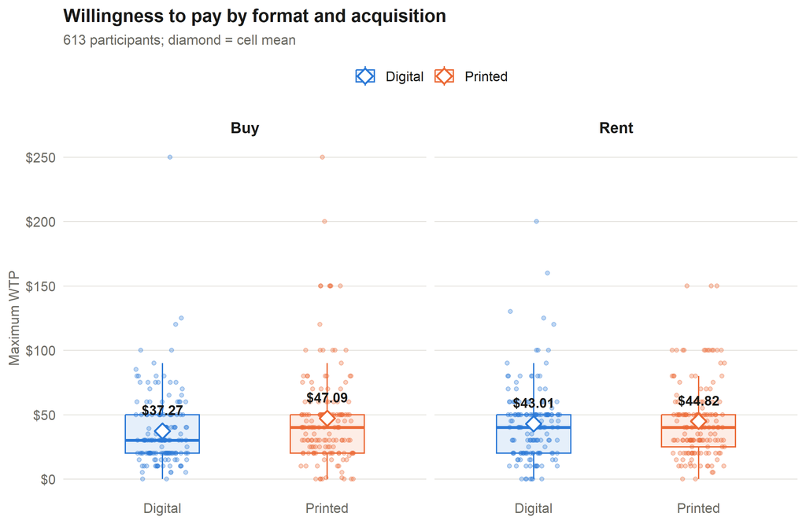

Figure 1: Each dot is one participant. Boxes show the median and interquartile range; the diamond is the cell mean. The printed premium under Buy is visible, but small relative to the spread.

```r
cell_mean <- aggregate(wtp ~ Acquisition + Format, d, mean)
names(cell_mean)[3] <- "m"

ggplot(d, aes(Format, wtp, colour = Format, fill = Format)) +
  geom_boxplot(width = 0.45, alpha = 0.12, outlier.shape = NA, linewidth = 0.5) +
  geom_jitter(width = 0.16, height = 0, alpha = 0.30, size = 1.1) +
  geom_point(data = cell_mean, aes(y = m), shape = 23, size = 3.4,
             fill = "white", stroke = 1.1) +
  geom_text(data = cell_mean, aes(y = m, label = sprintf("$%.2f", m)),
            vjust = -1.6, size = 3.4, fontface = "bold", colour = INK,
            show.legend = FALSE) +
  facet_wrap(~ Acquisition) +
  scale_colour_manual(values = PAL) + scale_fill_manual(values = PAL) +
  scale_y_continuous(labels = scales::dollar) +
  labs(title = "Willingness to pay by format and acquisition",
       subtitle = "613 participants; diamond = cell mean",
       x = NULL, y = "Maximum WTP") +
  theme_pod3()
```

## The distribution is skewed and zero-inflated

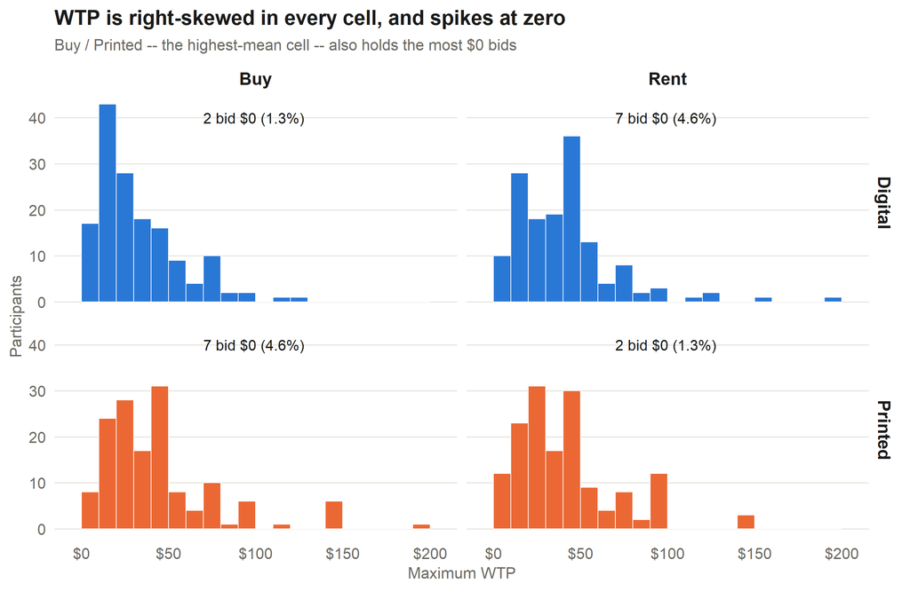

Figure 2: Binned at $10. The bar at $0 is the one that matters: 18 participants bid nothing, and they are not evenly spread across cells.

```r
zero_n <- aggregate(cbind(z = wtp == 0) ~ Acquisition + Format, d, sum)
zero_n$pct <- 100 * zero_n$z / aggregate(wtp ~ Acquisition + Format, d, length)$wtp

ggplot(d, aes(wtp, fill = Format)) +
  geom_histogram(binwidth = 10, boundary = 0, colour = "white", linewidth = 0.3) +
  geom_text(data = zero_n, aes(x = 70, y = 40,
            label = sprintf("%d bid $0 (%.1f%%)", z, pct)),
            inherit.aes = FALSE, hjust = 0, size = 3.3, colour = INK) +
  facet_grid(Format ~ Acquisition) +
  scale_fill_manual(values = PAL, guide = "none") +
  scale_x_continuous(labels = scales::dollar, limits = c(-5, 205)) +
  labs(title = "WTP is right-skewed in every cell, and spikes at zero",
       subtitle = "Buy / Printed -- the highest-mean cell -- also holds the most $0 bids",
       x = "Maximum WTP", y = "Participants") +
  theme_pod3()
```

```r
zt <- do.call(rbind, lapply(split(d, list(d$Acquisition, d$Format)), function(s)
  data.frame(Acquisition = s$Acquisition[1], Format = s$Format[1], n = nrow(s),
             `$0 bids` = sum(s$wtp == 0),
             `% zero` = sprintf("%.1f%%", 100 * mean(s$wtp == 0)),
             Median = scales::dollar(median(s$wtp)), check.names = FALSE)))
kable(zt, row.names = FALSE, caption = "Zero responses by cell.")
```

Table 1: Zero responses by cell.

| Acquisition | Format | n | $0 bids | % zero | Median |
| --- | --- | --- | --- | --- | --- |
| Buy | Digital | 154 | 2 | 1.3% | $30 |
| Rent | Digital | 153 | 7 | 4.6% | $40 |
| Buy | Printed | 153 | 7 | 4.6% | $40 |
| Rent | Printed | 153 | 2 | 1.3% | $40 |

## Participants answer in round numbers

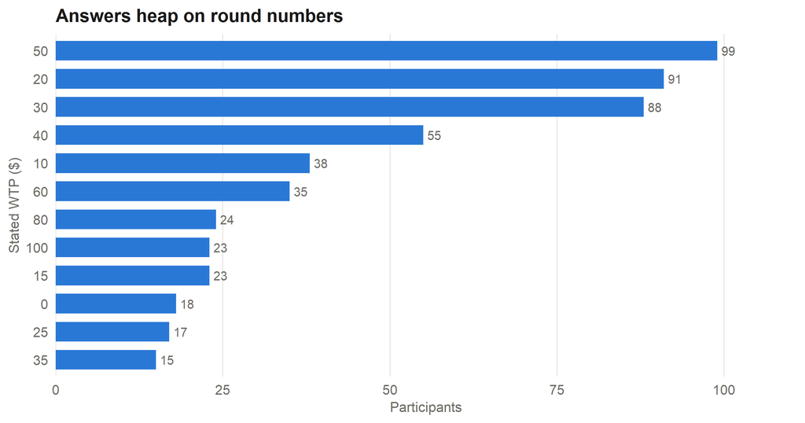

Figure 3: The 12 most common answers. Open-ended WTP heaps on multiples of $10, which is part of why rank-based tests behave well here.

```r
hp <- as.data.frame(table(d$wtp), stringsAsFactors = FALSE)
names(hp) <- c("wtp", "n")
hp$wtp <- as.numeric(hp$wtp)
hp <- head(hp[order(-hp$n), ], 12)

ggplot(hp, aes(reorder(factor(wtp), n), n)) +
  geom_col(fill = PAL[["Digital"]], width = 0.7) +
  geom_text(aes(label = n), hjust = -0.3, size = 3.2, colour = INK2) +
  coord_flip() +
  scale_y_continuous(expand = expansion(mult = c(0, 0.12))) +
  labs(title = "Answers heap on round numbers",
       x = "Stated WTP ($)", y = "Participants") +
  theme_pod3() +
  theme(panel.grid.major.y = element_blank(),
        panel.grid.major.x = element_line(colour = GRID, linewidth = 0.4))
```

# Summarized data

```r
skew <- function(x) mean((x - mean(x))^3) / sd(x)^3

ct <- do.call(rbind, lapply(split(d, list(d$Acquisition, d$Format)), function(s)
  data.frame(Acquisition = s$Acquisition[1], Format = s$Format[1], n = nrow(s),
             `Mean WTP` = sprintf("$%.2f", mean(s$wtp)),
             `Median WTP` = scales::dollar(median(s$wtp)),
             SD   = sprintf("%.2f", sd(s$wtp)),
             Skew = sprintf("%.2f", skew(s$wtp)),
             Ownership  = sprintf("%.2f", mean(s$ownership)),
             Permanence = sprintf("%.2f", mean(s$permanence)),
             Enjoyment  = sprintf("%.2f", mean(s$enjoy)),
             check.names = FALSE)))
kable(ct, row.names = FALSE,
      caption = "Cell means. Skewness is reported because it is the criterion the original authors used to decide whether to transform.")
```

Table 2: Cell means. Skewness is reported because it is the criterion the original authors used to decide whether to transform.

| Acquisition | Format | n | Mean WTP | Median WTP | SD | Skew | Ownership | Permanence | Enjoyment |
| --- | --- | --- | --- | --- | --- | --- | --- | --- | --- |
| Buy | Digital | 154 | $37.27 | $30 | 29.41 | 2.99 | 4.18 | 4.88 | 4.02 |
| Rent | Digital | 153 | $43.01 | $40 | 29.86 | 1.73 | 3.00 | 3.61 | 4.05 |
| Buy | Printed | 153 | $47.09 | $40 | 38.39 | 2.10 | 5.47 | 4.83 | 4.47 |
| Rent | Printed | 153 | $44.82 | $40 | 29.39 | 1.24 | 3.16 | 4.05 | 4.67 |

# Analyzed the way they analyzed it

**They did not transform, because their data were not skewed. Ours are.** In their Experiment 3 they report that WTP was skewed only for digital purchases, and that for that reason it was “not transformed.” Our data do not meet that condition. Using the same criterion they used (skewness > 1.96), **two of our four cells clear the threshold where one of theirs did** – Buy / Digital at 2.99 and Buy / Printed at 2.10, against their single skewed cell at 2.91. Applying their own decision rule to our data means transforming.

**We use the square root, because that is the transform they used.** The one time they transformed a skewed value measure – Experiment 1, pay-what-you-want donations – they applied a square root and ran nonparametric tests on the raw values. It also behaves correctly here: `sqrt(0) = 0`, so the 18 participants who bid nothing stay in the analysis without distorting it, where `log(WTP + 1)` would place them about 3.5 log-units below a $30 answer. Raw dollars are reported alongside throughout, because their published figures are in dollars and the comparison at the top of this document only works on that scale.

```r
kable(peta(aov(sqrt(wtp) ~ format * acquisition, data = d)),
      caption = "Primary analysis: 2 x 2 between-subjects ANOVA on sqrt(WTP).")
```

Primary analysis: 2 x 2 between-subjects ANOVA on sqrt(WTP).

| Term | F | df | p | Partial eta2 |
| --- | --- | --- | --- | --- |
| format | 4.43 | 1, 609 | 0.036 | 0.007 |
| acquisition | 1.22 | 1, 609 | 0.270 | 0.002 |
| format:acquisition | 0.97 | 1, 609 | 0.325 | 0.002 |

# The interaction, in detail

The interaction asks one question: **is the printed-over-digital gap larger when you buy than when you rent?** It is a difference of differences, so a single dollar figure carries it.

```r
m  <- lm(wtp ~ format * acquisition, data = d)
co <- summary(m)$coefficients["formatphysical:acquisitionbuy", ]
ci <- confint(m)["formatphysical:acquisitionbuy", ]
ours_est <- unname(co["Estimate"]); ours_se <- unname(co["Std. Error"])

# Their Experiment 3, recovered from the reported cell means and F.
them_dd <- (87.81 - 44.90) - (58.97 - 47.17)
them_se <- them_dd / sqrt(7.87)

kable(data.frame(
  Study = c("Atasoy & Morewedge (N = 275)", "Pod 3 (N = 613)"),
  `Difference of differences` = c(
    sprintf("+$%.2f (SE $%.2f), 95%% CI [$%.2f, $%.2f]",
            them_dd, them_se, them_dd - 1.96 * them_se, them_dd + 1.96 * them_se),
    sprintf("+$%.2f (SE $%.2f), 95%% CI [$%.2f, $%.2f]",
            ours_est, ours_se, ci[1], ci[2])),
  Test = c("F(1, 271) = 7.87, p = .005",
           sprintf("F(1, 609) = %.2f, p = %.3f", co["t value"]^2, co["Pr(>|t|)"])),
  check.names = FALSE), row.names = FALSE,
  caption = "Same sign, about a quarter the size.")
```

Same sign, about a quarter the size.

| Study | Difference of differences | Test |
| --- | --- | --- |
| Atasoy & Morewedge (N = 275) | +$31.11 (SE $11.09), 95% CI [$9.37, $52.85] | F(1, 271) = 7.87, p = .005 |
| Pod 3 (N = 613) | +$8.01 (SE $5.17), 95% CI [$-2.13, $18.16] | F(1, 609) = 2.41, p = 0.121 |

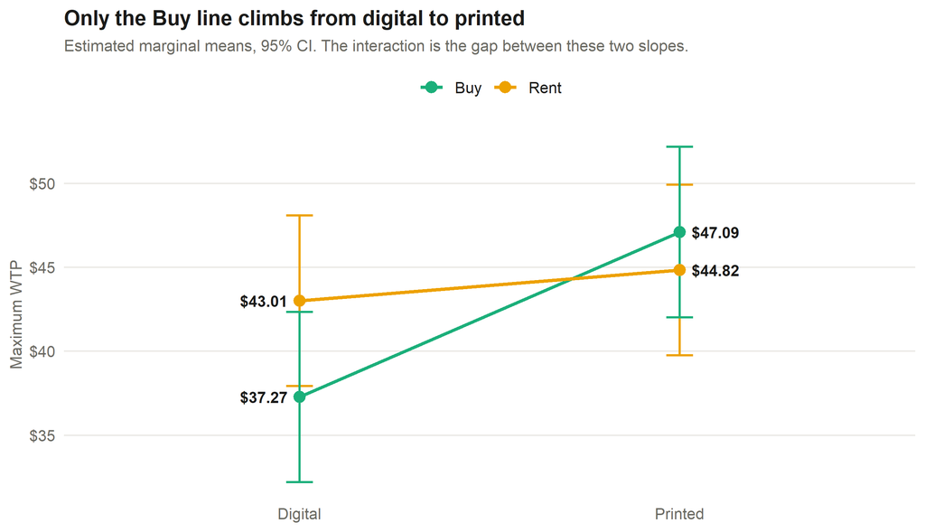

Figure 4: Cell means with 95% confidence intervals. The interaction is the difference in slopes: the Buy line climbs from digital to printed, the Rent line is flat. The intervals are wide enough that the difference between those two slopes is not resolvable at this N.

```r
em <- as.data.frame(emmeans(m, ~ format | acquisition))
em$Format <- factor(ifelse(em$format == "physical", "Printed", "Digital"),
                    levels = c("Digital", "Printed"))
em$Acquisition <- factor(ifelse(em$acquisition == "buy", "Buy", "Rent"),
                         levels = c("Buy", "Rent"))

em$hj <- ifelse(em$Format == "Digital", 1.25, -0.25)

ggplot(em, aes(Format, emmean, colour = Acquisition, group = Acquisition)) +
  geom_line(linewidth = 1) +
  geom_errorbar(aes(ymin = lower.CL, ymax = upper.CL), width = 0.07, linewidth = 0.7) +
  geom_point(size = 3) +
  geom_text(aes(label = scales::dollar(emmean, accuracy = 0.01), hjust = hj),
            colour = INK, size = 3.4, fontface = "bold", show.legend = FALSE) +
  scale_colour_manual(values = PAL_ACQ) +
  scale_y_continuous(labels = scales::dollar) +
  scale_x_discrete(expand = expansion(add = 0.62)) +
  labs(title = "Only the Buy line climbs from digital to printed",
       subtitle = "Estimated marginal means, 95% CI. The interaction is the gap between these two slopes.",
       x = NULL, y = "Maximum WTP") +
  theme_pod3()
```

**1. It is not underpowered for their effect.**

```r
pw <- function(delta, se) pnorm(delta / se - 1.959964) + pnorm(-delta / se - 1.959964)
kable(data.frame(
  Question = c("Power to detect THEIR interaction at our N",
               "Power to detect OUR OWN interaction at our N",
               "Smallest interaction we had 80% power for",
               "N needed for 80% power on our estimate"),
  Answer = c(sprintf("%.1f%%", 100 * pw(them_dd, ours_se)),
             sprintf("%.1f%%", 100 * pw(ours_est, ours_se)),
             sprintf("$%.2f", 2.801592 * ours_se),
             sprintf("%.0f participants", N * (ours_se / (ours_est / 2.801592))^2)),
  check.names = FALSE), row.names = FALSE)
```

| Question | Answer |
| --- | --- |
| Power to detect THEIR interaction at our N | 100.0% |
| Power to detect OUR OWN interaction at our N | 34.1% |
| Smallest interaction we had 80% power for | $14.48 |
| N needed for 80% power on our estimate | 2000 participants |

**2. We did not contradict them.** Our estimate is smaller than theirs, but each number carries a margin of error – roughly +/-$10 for ours, +/-$22 for theirs – and those margins overlap.

```r
dz <- them_dd - ours_est; sez <- sqrt(them_se^2 + ours_se^2)
cat(sprintf("Theirs minus ours = $%.2f, SE = $%.2f, z = %.2f, p = %.3f",
            dz, sez, dz / sez, 2 * pnorm(-abs(dz / sez))))
```

```
Theirs minus ours = $23.10, SE = $12.23, z = 1.89, p = 0.059
```

In plain terms: we did not get a different answer from theirs. We got a fuzzier one pointing the same way.

# Robustness checks

## How willingness to pay is transformed

```r
spec <- function(tf, label, back) {
  dd <- d; dd$y <- tf(dd$wtp)
  fit <- lm(y ~ format * acquisition, data = dd)
  s   <- summary(aov(y ~ format * acquisition, data = dd))[[1]]
  rn  <- trimws(rownames(s))
  e   <- as.data.frame(emmeans(fit, pairwise ~ format | acquisition)$contrasts)
  g <- function(a) {
    r <- e[e$acquisition == a, ]
    sprintf("%s, p = %.3f", back(-r$estimate), r$p.value)
  }
  data.frame(Specification = label, `Buy gap` = g("buy"), `Rent gap` = g("rent"),
             Interaction = sprintf("p = %.3f", s[which(rn == "format:acquisition"), "Pr(>F)"]),
             check.names = FALSE)
}

dollars <- function(x) sprintf("%+.2f", x)
pct     <- function(x) sprintf("%+.1f%%", 100 * (exp(x) - 1))

kable(rbind(
  spec(sqrt,                    "sqrt(WTP) (primary)",   dollars),
  spec(identity,                "Raw dollars",           dollars),
  spec(function(x) log(x + 1),  "log(WTP + 1)",          pct)
), row.names = FALSE, caption = "Every specification, printed minus digital.")
```

Every specification, printed minus digital.

| Specification | Buy gap | Rent gap | Interaction |
| --- | --- | --- | --- |
| sqrt(WTP) (primary) | +0.59, p = 0.029 | +0.21, p = 0.431 | p = 0.325 |
| Raw dollars | +9.83, p = 0.007 | +1.81, p = 0.621 | p = 0.121 |
| log(WTP + 1) | +12.6%, p = 0.247 | +11.7%, p = 0.282 | p = 0.954 |

```r
wb <- wilcox.test(wtp ~ format, data = subset(d, acquisition == "buy"))
wr <- wilcox.test(wtp ~ format, data = subset(d, acquisition == "rent"))
cat(sprintf("Wilcoxon rank-sum: buy p = %.3f, rent p = %.3f", wb$p.value, wr$p.value))
```

```
Wilcoxon rank-sum: buy p = 0.010, rent p = 0.698
```

**The log(WTP + 1) null is a zero-inflation artifact.** Because `log(0 + 1) = 0` lands about 3.5 log-units below a $30 answer, the 7 zero bids in Buy / Printed drag that cell’s geometric mean from $47.09 to $32.52 and erase the gap. That is a fact about the 18 participants who bid nothing, not about the format effect – which is the reason the square root, where `sqrt(0) = 0` costs nothing, is the primary analysis.

## Medians instead of means

With a skewed, heaped, zero-inflated outcome, the median is arguably the better summary. Gaps are Hodges–Lehmann median shifts with Wilcoxon tests; the interaction is from median (quantile) regression with bootstrapped standard errors, which handles the ties created by round-number answers.

```r
suppressMessages(library(quantreg))
set.seed(20261112)

rqm <- summary(rq(wtp ~ format * acquisition, tau = 0.5, data = d),
               se = "boot", R = 2000)$coefficients
hl <- function(a) {
  w <- wilcox.test(wtp ~ format, data = subset(d, acquisition == a), conf.int = TRUE)
  sprintf("%s, p = %.3f", money(-w$estimate), w$p.value)
}
mr <- contrasts_pooled(d$wtp)

kable(data.frame(
  Analysis = c("Means (raw dollars)", "Medians"),
  `Buy gap`  = c(sprintf("%s, p = %s", money(mr$Diff[1]), mr$p[1]), hl("buy")),
  `Rent gap` = c(sprintf("%s, p = %s", money(mr$Diff[2]), mr$p[2]), hl("rent")),
  Interaction = c(sprintf("p = %s", pick(av, "format:acquisition", "p")),
                  sprintf("%s, p = %.3f",
                          money(rqm["formatphysical:acquisitionbuy", "Value"]),
                          rqm["formatphysical:acquisitionbuy", "Pr(>|t|)"])),
  check.names = FALSE), row.names = FALSE,
  caption = "Printed minus digital, means against medians.")
```

Printed minus digital, means against medians.

| Analysis | Buy gap | Rent gap | Interaction |
| --- | --- | --- | --- |
| Means (raw dollars) | +$9.83, p = 0.007 | +$1.81, p = 0.621 | p = 0.121 |
| Medians | +$10.00, p = 0.010 | +$0.00, p = 0.698 | +$10.00, p = 0.098 |

On medians the predicted pattern is as clean as it gets: a **$10 printed premium under buy** (*p* = .010) and **exactly zero under rent** (*p* = .70). The interaction is still short of significance (*p* = .098), but it is closer than the mean-based test, and the rent gap is literally nil.

The median analysis also sharpens the oddity in the digital cells: median WTP is $30 to buy a digital textbook against $40 to rent one, a $10 difference that is significant in the quantile regression (*p* = .002). Buying strictly dominates renting, so this is worth checking against the scenario wording before it is built on.

## Manipulation-check failures

47 of the 613 participants (7.7%) failed at least one manipulation check. They are kept in every analysis above; the only question is whether the headline results look different without them.

```r
dm <- subset(d, mc_both_ok)

gap <- function(dat, dv, a) {
  dd <- dat; dd$y <- dd[[dv]]
  e <- as.data.frame(emmeans(lm(y ~ format * acquisition, data = dd),
                             pairwise ~ format | acquisition)$contrasts)
  r <- e[e$acquisition == a, ]
  sprintf("%+.2f, p = %.3f", -r$estimate, r$p.value)
}
inter_p <- function(dat, dv) {
  dd <- dat; dd$y <- dd[[dv]]
  s <- summary(aov(y ~ format * acquisition, data = dd))[[1]]
  p <- s[which(trimws(rownames(s)) == "format:acquisition"), "Pr(>F)"]
  if (p < .001) formatC(p, format = "e", digits = 1) else sprintf("p = %.3f", p)
}

kable(data.frame(
  `Headline result` = c("WTP, buy gap (printed - digital)", "WTP interaction",
                        "Ownership interaction"),
  `All 613` = c(gap(d, "wtp", "buy"), inter_p(d, "wtp"), inter_p(d, "ownership")),
  `MC-passing (566)` = c(gap(dm, "wtp", "buy"), inter_p(dm, "wtp"),
                         inter_p(dm, "ownership")),
  check.names = FALSE), row.names = FALSE,
  caption = sprintf("The %d participants who failed a check are kept in; this shows what happens if they are not.",
                    N - nrow(dm)))
```

The 47 participants who failed a check are kept in; this shows what happens if they are not.

| Headline result | All 613 | MC-passing (566) |
| --- | --- | --- |
| WTP, buy gap (printed - digital) | +9.83, p = 0.007 | +10.39, p = 0.007 |
| WTP interaction | p = 0.121 | p = 0.083 |
| Ownership interaction | 5.6e-07 | 1.5e-06 |

```r
own <- t.test(ownership ~ mc_both_ok, data = d)
wt  <- t.test(wtp ~ mc_both_ok, data = d)
```

**Failure is unevenly distributed across conditions, which is a comparability problem.** Excluding on this check would remove a different fraction of each cell, so the four groups being compared would no longer be drawn from the population in the same way.

```r
fr <- tapply(!d$mc_both_ok, list(d$Acquisition, d$Format), mean) * 100
kable(data.frame(Acquisition = rownames(fr),
                 Digital = sprintf("%.1f%%", fr[, "Digital"]),
                 Printed = sprintf("%.1f%%", fr[, "Printed"]),
                 check.names = FALSE), row.names = FALSE,
      caption = "Manipulation-check failure rate by cell. Buying a new printed textbook is the most familiar scenario and the easiest to recall correctly, so the check is effectively harder in the less prototypical conditions.")
```

Manipulation-check failure rate by cell. Buying a new printed textbook is the most familiar scenario and the easiest to recall correctly, so the check is effectively harder in the less prototypical conditions.

| Acquisition | Digital | Printed |
| --- | --- | --- |
| Buy | 9.7% | 2.6% |
| Rent | 9.8% | 8.5% |

**Failers differ on the mediator but not the outcome.** They score lower on psychological ownership (3.35 vs. 4.01, p = 0.004) while being indistinguishable on WTP (p = 0.44). The check is picking up something tied to the mechanism construct, not to effort – which is a further reason to report the comparison rather than exclude.

# The mediation model

This is their Experiment 2 model, run on our data: product format (0 = digital, 1 = printed) with **psychological ownership and permanence as parallel mediators** of willingness to pay, and percentile confidence intervals from **5,000 bootstrap iterations**, following Hayes (2013) as they did.

**Why the buy condition only.** Their Experiment 2 asked what participants would pay to acquire a book; it had no rental arm. The buy cells are the matching sample, so the mediation runs on those 307 participants. Pooling all 613 would mix in a condition where the format effect does not exist.

```r
set.seed(20261112)
B  <- 5000
d$X <- as.integer(d$format == "physical")
buy <- subset(d, acquisition == "buy")
buy <- buy[complete.cases(buy[c("wtp", "ownership", "permanence", "enjoy", "X")]), ]

est <- function(s, meds) {
  a  <- sapply(meds, function(m) coef(lm(reformulate("X", m), data = s))["X"])
  my <- lm(reformulate(c(meds, "X"), "wtp"), data = s)
  b  <- coef(my)[meds]
  c(setNames(a * b, paste0("ind_", meds)),
    direct = unname(coef(my)["X"]),
    total  = unname(coef(lm(wtp ~ X, data = s))["X"]))
}
boot <- function(s, meds) {
  k <- names(est(s, meds))
  out <- matrix(NA_real_, B, length(k), dimnames = list(NULL, k))
  for (i in seq_len(B)) out[i, ] <- est(s[sample(nrow(s), nrow(s), TRUE), ], meds)
  out
}
ci_txt <- function(e, bo, k) {
  q <- quantile(bo[, k], c(.025, .975), na.rm = TRUE)
  sprintf("%s, 95%% CI [%.2f, %.2f]%s", money(e[[k]]), q[1], q[2],
          if (q[1] > 0 | q[2] < 0) " *" else "")
}

M2 <- c("ownership", "permanence")
e2 <- est(buy, M2); b2 <- boot(buy, M2)

kable(data.frame(
  Effect = c("Indirect via psychological ownership", "Indirect via permanence",
             "Direct effect of format (c')", "Total effect of format (c)"),
  `Atasoy & Morewedge, Exp 2` = c("0.96, 95% CI [0.21, 2.08] *",
                                  "0.20, 95% CI [-0.32, 0.68]",
                                  "2.18, 95% CI [0.62, 3.74] *",
                                  "not reported"),
  `Pod 3, buy condition` = c(ci_txt(e2, b2, "ind_ownership"),
                             ci_txt(e2, b2, "ind_permanence"),
                             ci_txt(e2, b2, "direct"),
                             ci_txt(e2, b2, "total")),
  check.names = FALSE), row.names = FALSE,
  caption = "Their numbers as published, beside ours. * = 95% CI excludes zero. Their Experiment 2 priced a popular book and ours a textbook, so compare the pattern, not the magnitudes.")
```

Their numbers as published, beside ours. * = 95% CI excludes zero. Their Experiment 2 priced a popular book and ours a textbook, so compare the pattern, not the magnitudes.

| Effect | Atasoy & Morewedge, Exp 2 | Pod 3, buy condition |
| --- | --- | --- |
| Indirect via psychological ownership | 0.96, 95% CI [0.21, 2.08] * | +$3.33, 95% CI [-0.41, 7.05] |
| Indirect via permanence | 0.20, 95% CI [-0.32, 0.68] | -$0.06, 95% CI [-0.89, 0.45] |
| Direct effect of format (c’) | 2.18, 95% CI [0.62, 3.74] * | +$6.55, 95% CI [-2.37, 15.71] |
| Total effect of format (c) | not reported | +$9.83, 95% CI [2.43, 17.42] * |

```r
# Enjoyment as a third mediator -- reported in the text, not part of the model.
M3 <- c("ownership", "permanence", "enjoy")
e3 <- est(buy, M3); b3 <- boot(buy, M3)
enj_txt <- ci_txt(e3, b3, "ind_enjoy")
own_txt <- ci_txt(e3, b3, "ind_ownership")

# Path coefficients and their own tests, for the figure labels.
star <- function(p) if (p < .05) "*" else ""
pa  <- summary(lm(ownership  ~ X, data = buy))$coefficients["X", ]
pp  <- summary(lm(permanence ~ X, data = buy))$coefficients["X", ]
pb  <- summary(lm(wtp ~ ownership + permanence + X, data = buy))$coefficients
pc  <- summary(lm(wtp ~ X, data = buy))$coefficients["X", ]
lab_a_own  <- sprintf("a = %+.2f%s",  pa["Estimate"], star(pa["Pr(>|t|)"]))
lab_a_perm <- sprintf("a = %+.2f%s",  pp["Estimate"], star(pp["Pr(>|t|)"]))
lab_b_own  <- sprintf("b = $%.2f%s",  pb["ownership", "Estimate"],  star(pb["ownership", "Pr(>|t|)"]))
lab_b_perm <- sprintf("b = $%.2f%s",  pb["permanence", "Estimate"], star(pb["permanence", "Pr(>|t|)"]))
lab_c      <- sprintf("direct c' = $%.2f%s    (total c = $%.2f%s)",
                      pb["X", "Estimate"], star(pb["X", "Pr(>|t|)"]),
                      pc["Estimate"], star(pc["Pr(>|t|)"]))
```

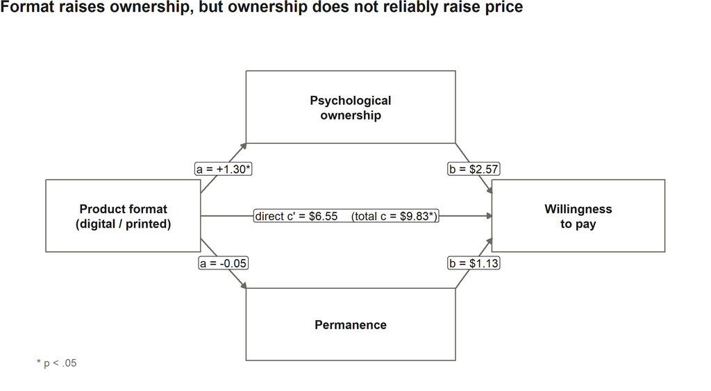

Figure 5: Their Figure 4 model, estimated on our buy condition. A star marks a path whose own test is significant at p < .05. Coefficients are unstandardized: a-paths in scale points, b-paths in dollars per scale point. Only the format-to-ownership path and the total effect clear significance; the ownership-to-WTP path does not, which is why the indirect effect cannot be established.

```r
bx <- data.frame(
  x = c(1, 3.5, 3.5, 6), y = c(2, 3.2, 0.8, 2),
  w = c(1.7, 2.3, 2.3, 1.9), h = 0.8,
  lab = c("Product format\n(digital / printed)", "Psychological\nownership",
          "Permanence", "Willingness\nto pay"))
ar <- arrow(length = unit(0.16, "cm"), type = "closed")

ggplot() +
  geom_rect(data = bx, aes(xmin = x - w/2, xmax = x + w/2,
                           ymin = y - h/2, ymax = y + h/2),
            fill = NA, colour = INK2, linewidth = 0.5) +
  geom_text(data = bx, aes(x, y, label = lab), size = 3.5, lineheight = 1.0,
            colour = INK, fontface = "bold") +
  annotate("segment", x = 1.85, y = 2.25, xend = 2.35, yend = 2.80,
           colour = INK2, linewidth = 0.6, arrow = ar) +
  annotate("segment", x = 4.65, y = 2.80, xend = 5.05, yend = 2.25,
           colour = INK2, linewidth = 0.6, arrow = ar) +
  annotate("segment", x = 1.85, y = 1.75, xend = 2.35, yend = 1.20,
           colour = INK2, linewidth = 0.6, arrow = ar) +
  annotate("segment", x = 4.65, y = 1.20, xend = 5.05, yend = 1.75,
           colour = INK2, linewidth = 0.6, arrow = ar) +
  annotate("segment", x = 1.85, y = 2.00, xend = 5.05, yend = 2.00,
           colour = INK2, linewidth = 0.6, arrow = ar) +
  annotate("label", x = 2.10, y = 2.52, size = 3.3, colour = INK,
           fill = "white", label.size = 0,
           label.padding = unit(0.12, "lines"), label = lab_a_own) +
  annotate("label", x = 4.85, y = 2.52, size = 3.3, colour = INK,
           fill = "white", label.size = 0,
           label.padding = unit(0.12, "lines"), label = lab_b_own) +
  annotate("label", x = 2.10, y = 1.48, size = 3.3, colour = INK,
           fill = "white", label.size = 0,
           label.padding = unit(0.12, "lines"), label = lab_a_perm) +
  annotate("label", x = 4.85, y = 1.48, size = 3.3, colour = INK,
           fill = "white", label.size = 0,
           label.padding = unit(0.12, "lines"), label = lab_b_perm) +
  annotate("label", x = 3.45, y = 2.00, size = 3.3, colour = INK,
           fill = "white", label.size = 0,
           label.padding = unit(0.12, "lines"), label = lab_c) +
  annotate("text", x = 0.05, y = 0.38, hjust = 0, size = 3.0, colour = INK2,
           label = "* p < .05") +
  coord_cartesian(xlim = c(0, 7.1), ylim = c(0.25, 3.95)) +
  labs(title = "Format raises ownership, but ownership does not reliably raise price") +
  theme_void(base_size = 12) +
  theme(plot.title = element_text(colour = INK, face = "bold", size = 13,
                                  margin = margin(b = 6)))
```

**Read the permanence path as uninformative, not as a null.** Our permanence items moved with buy/rent rather than with format (see Caveats), so they did not capture the durability construct the model needs them to. We cannot use this result to rule permanence out as a mechanism the way they did.

**The weak link is the b-path.** Format moves ownership exactly as the account requires (a = +1.30, *p* < .0001). What is imprecise is ownership to WTP (b = $2.57, *p* = .11). Write this up as *consistent with* ownership mediation, not as established mediation.

**One deviation from their model, stated.** We also measured anticipated enjoyment, which they did not. It is deliberately **not** in the model above, because including it would be a departure from the analysis we set out to replicate. For completeness: added as a third parallel mediator its indirect effect is +$0.47, 95% CI [-0.68, 1.98], and the ownership indirect effect moves to +$3.13, 95% CI [-0.75, 6.95] – that is, enjoyment neither mediates nor absorbs the ownership path. We report it because we collected it, not as part of the tested model.

```r
kable(peta(aov(ownership ~ format * acquisition, data = d)),
      caption = "Psychological ownership: the mediator's own 2 x 2.")
```

Psychological ownership: the mediator’s own 2 x 2.

| Term | F | df | p | Partial eta2 |
| --- | --- | --- | --- | --- |
| format | 41.69 | 1, 609 | 2.2e-10 | 0.064 |
| acquisition | 240.05 | 1, 609 | 6.9e-46 | 0.283 |
| format:acquisition | 25.58 | 1, 609 | 5.6e-07 | 0.040 |

# Caveats

## The permanence items are not measuring what they were meant to measure

Permanence is the second mediator in their model, and the idea behind it is specific: product format should change how permanent or long-lasting the good seems – a printed book outlasts a Kindle licence – and that durability should drive value. For the measure to do that job it has to move with **format**.

In our data it moves with **buy/rent** instead.

```r
kable(peta(aov(permanence ~ format * acquisition, data = d)),
      caption = "Permanence: strongly moved by acquisition, barely by format.")
```

Permanence: strongly moved by acquisition, barely by format.

| Term | F | df | p | Partial eta2 |
| --- | --- | --- | --- | --- |
| format | 3.65 | 1, 609 | 0.056 | 0.006 |
| acquisition | 102.09 | 1, 609 | 2.7e-22 | 0.144 |
| format:acquisition | 5.86 | 1, 609 | 0.016 | 0.010 |

```r
pm <- tapply(d$permanence, list(d$Acquisition, d$Format), mean)
kable(data.frame(Acquisition = rownames(pm),
                 Digital = sprintf("%.2f", pm[, "Digital"]),
                 Printed = sprintf("%.2f", pm[, "Printed"]),
                 `Printed - digital` = sprintf("%+.2f", pm[, "Printed"] - pm[, "Digital"]),
                 check.names = FALSE), row.names = FALSE,
      caption = "Cell means on the 4-item permanence scale.")
```

Cell means on the 4-item permanence scale.

| Acquisition | Digital | Printed | Printed - digital |
| --- | --- | --- | --- |
| Buy | 4.88 | 4.83 | -0.05 |
| Rent | 3.61 | 4.05 | +0.44 |

Participants appear to have read the items as permanence of **access** – how long you get to keep it, 180 days versus forever – rather than durability of the **object**. Under buy, where the format contrast should be sharpest, the difference is essentially nil and runs the wrong way. Two consequences:

- **The null permanence path in the mediation above is not evidence against permanence.** The measure did not capture the construct, so that path is uninformative, not negative. We cannot claim to have ruled permanence out as a mechanism the way they did.
- **The items need rewriting before reuse**, with wording pinned to the object (“this copy will still be usable in ten years”) rather than to the term of access.